# Interspecific Floral Morphology Variation among Iris Species

## To accompany the application from W. Pitchers for *#ecomodelling* position

> This is an [R Markdown](http://rmarkdown.rstudio.com) Notebook to document an analysis of the `iris` dataset that is packaged with the base installation of **R**.

Our dataframe contains 150 observations of Irises, each with values for a variable identifying `Species` (a factor), and four numeric measurements; the length and width of both petals and sepals.

```r
data( iris )

# iris %>% summary()

iris %>% transmute( Species, Sepal.Length, Sepal.Width, Petal.Length, Petal.Width ) %>% data.table()
```

| Species | Sepal.Length | Sepal.Width | Petal.Length | Petal.Width |
| --- | --- | --- | --- | --- |
| setosa | 5.1 | 3.5 | 1.4 | 0.2 |
| setosa | 4.9 | 3.0 | 1.4 | 0.2 |
| setosa | 4.7 | 3.2 | 1.3 | 0.2 |
| setosa | 4.6 | 3.1 | 1.5 | 0.2 |
| setosa | 5.0 | 3.6 | 1.4 | 0.2 |
| setosa | 5.4 | 3.9 | 1.7 | 0.4 |
| setosa | 4.6 | 3.4 | 1.4 | 0.3 |
| setosa | 5.0 | 3.4 | 1.5 | 0.2 |
| setosa | 4.4 | 2.9 | 1.4 | 0.2 |
| setosa | 4.9 | 3.1 | 1.5 | 0.1 |

[output cut: 140 more lines]

```r
NA
```

## Question 1: Do Species Differ?

Since were dealing with 4 putatively independent numeric variables, a MANOVA would be an appropriate way to address this question. (Since we have a single predictor – `Species` – it should make no difference whether we use type II or type III sums of squares.)

Here we can see that the matrix of all four measurements predicts species ID with a high degree of confidence;

```r
dep_vars <- with( iris, cbind( Sepal.Length, Sepal.Width, Petal.Length, Petal.Width ))

mod <- lm( dep_vars ~ iris$Species )

mod %>% Anova( test.statistic="Wilks" )
```

```
Type II MANOVA Tests: Wilks test statistic
             Df test stat approx F num Df den Df    Pr(>F)
iris$Species  2  0.023439   199.15      8    288 < 2.2e-16 ***
---
Signif. codes:  0 ‘***’ 0.001 ‘**’ 0.01 ‘*’ 0.05 ‘.’ 0.1 ‘ ’ 1
```

However, we ought to check that our data meets the MANOVA assumptions before we conclude…

```r
cor( dep_vars ) %>% round( 2 )
```

```
             Sepal.Length Sepal.Width Petal.Length Petal.Width
Sepal.Length         1.00       -0.12         0.87        0.82
Sepal.Width         -0.12        1.00        -0.43       -0.37
Petal.Length         0.87       -0.43         1.00        0.96
Petal.Width          0.82       -0.37         0.96        1.00
```

We can enforce remove this multicollinearity by using principal component rotation, giving us 4 “PC’s” that are orthogonal to each other.

```r
pc_vars <- prcomp( dep_vars )$x

iris_pca <- cbind( iris, pc_vars )

cor( pc_vars ) %>% round( 2 )
```

```
    PC1 PC2 PC3 PC4
PC1   1   0   0   0
PC2   0   1   0   0
PC3   0   0   1   0
PC4   0   0   0   1
```

Re-running the one-way MANOVA using the PC’s in place of the raw measures reassures me that the multicollinearity is not problematic for the result;

```r
mod_pc <- lm( pc_vars ~ iris$Species )

mod_pc%>% Anova( test.statistic="Wilks" )
```

```
Type II MANOVA Tests: Wilks test statistic
             Df test stat approx F num Df den Df    Pr(>F)
iris$Species  2  0.023439   199.15      8    288 < 2.2e-16 ***
---
Signif. codes:  0 ‘***’ 0.001 ‘**’ 0.01 ‘*’ 0.05 ‘.’ 0.1 ‘ ’ 1
```

## *How* do the Species Differ?

In the first instance, I visualized the the spread of measurement values using violin plots. We can see that the differences are more marked among the petal measurements than those of the sepals. Note that the medians and interquartile ranges of each measure are quite displaced among species – this suggests that univariate analyses of each measure would find significant differences. Given the correlation among variables however, it is more efficient to take a multivariate view.

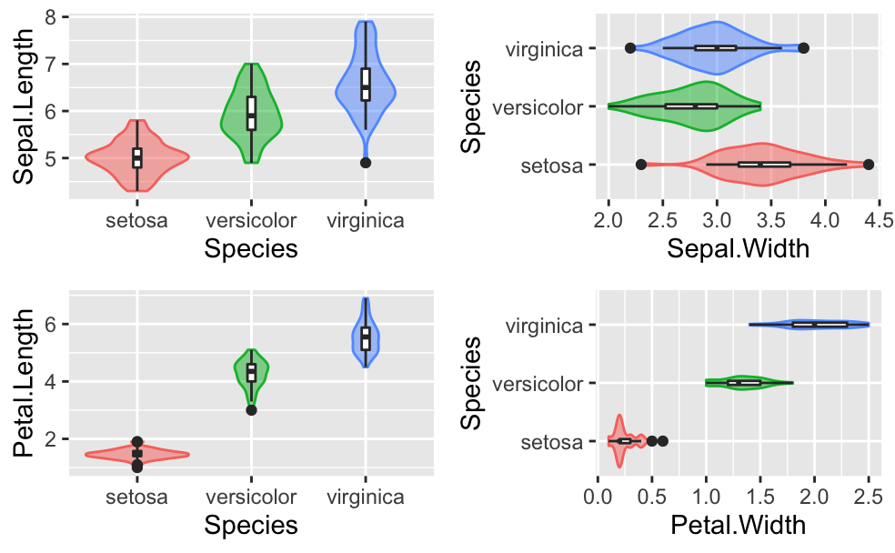

```r
v_sl <- iris %>% ggplot( aes( x=Species, y=Sepal.Length )) +
        geom_violin( aes( col=Species, fill=Species ), alpha=.5, show.legend=FALSE) +
        geom_boxplot(width=0.07 )
v_sw <- iris %>% ggplot( aes( x=Species, y=Sepal.Width  )) +
        geom_violin( aes( col=Species, fill=Species ), alpha=.5, show.legend=FALSE) +
        geom_boxplot(width=0.07) + coord_flip()
v_pl <- iris %>% ggplot( aes( x=Species, y=Petal.Length )) +
        geom_violin( aes( col=Species, fill=Species ), alpha=.5, show.legend=FALSE) +
        geom_boxplot(width=0.07)
v_pw <- iris %>% ggplot( aes( x=Species, y=Petal.Width  )) +
        geom_violin( aes( col=Species, fill=Species ), alpha=.5, show.legend=FALSE) +
        geom_boxplot(width=0.07) + coord_flip()

plot_grid( v_sl, v_sw, v_pl, v_pw )
```

```r
print( "Proportian of variance for PC's 1:4" )
```

```
[1] "Proportian of variance for PC's 1:4"
```

```r
round( prcomp( dep_vars )$sdev / sum( prcomp( dep_vars )$sdev  ), 2 )
```

```
[1] 0.69 0.17 0.09 0.05
```

One this scatter-plot of PC1 vs. PC2, we can see that *Iris setosa* separates clearly from *I. versicolor* & *I. virginica* along PC1, with a less clear separation **between** *I. versicolor* and *I. virginica*. PC2 shows a similarly subtle separation between *I. versicolor* and *I. setosa* & *I. virginica*.

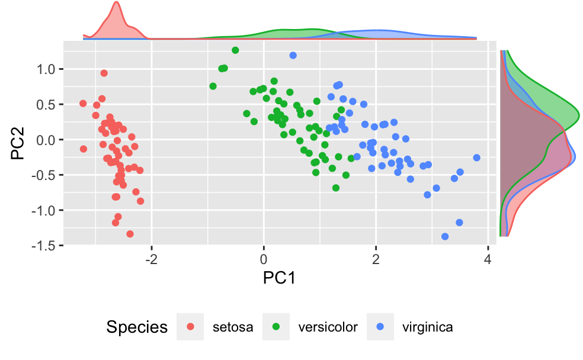

```r
p <- iris_pca %>% ggplot( aes( x=PC1, y=PC2, col=Species )) + geom_point()
p <- p + theme( legend.position="bottom" )
p <- ggMarginal( p, type = "density", groupColour=TRUE, groupFill=TRUE )
p
```

Looking at the PC loading matrix for our four variables, we can summarize their meaning as follows:

- PC1 is driven primarily by petal length, with lesser contributions of petal width and sepal length.
- PC2 primarily represents sepal width and sepal length.

```r
prcomp( dep_vars )$rotation %>% round( 2 )
```

```
               PC1   PC2   PC3   PC4
Sepal.Length  0.36 -0.66  0.58  0.32
Sepal.Width  -0.08 -0.73 -0.60 -0.32
Petal.Length  0.86  0.17 -0.08 -0.48
Petal.Width   0.36  0.08 -0.55  0.75
```

To summarize in the most simple form; *Iris setosa* is distinguished from its conspecifics mostly by its shorter petals, and *I. versicolor* differs from the other two species primarily in the shape of its sepals.